# Two-Sample Means (Independent) - Week 2, Lecture 1

Author

Hector Gavilanes

```r
library(tidyverse)
library(gsheet)
```

**A large credit union awards quarterly bonuses to its employees. To ensure fairness across departments, data on the bonuses are regularly reviewed for equality. Consider the data in the following Google Sheet, which includes the bonus percentage for each employee in two departments.**

```r
data <- as_tibble(gsheet2tbl("https://docs.google.com/spreadsheets/d/1q0Ouhr6hGBDp-5oyQuYGcsWTLrsayywVHJS7o17Sm6Y/edit?usp=sharing"))
```

#### 1. Summarize the data. Provide appropriate summary statistics for the study population.

```r
summary(data)
```

```
  Department            Bonus
 Length:60          Min.   : 6.200
 Class :character   1st Qu.: 8.700
 Mode  :character   Median : 9.150
                    Mean   : 9.223
                    3rd Qu.: 9.700
                    Max.   :12.000
```

#### 2. Construct the 99% confidence interval for the difference in bonuses for the two departments.

```r
t.test(Bonus ~ Department,
       data = data,
       conf.level = 0.99)
```

```
    Welch Two Sample t-test

data:  Bonus by Department
t = 3.9013, df = 43.587, p-value = 0.000327
alternative hypothesis: true difference in means between group Credit and group Mortgage is not equal to 0
99 percent confidence interval:
 0.3560411 1.9439589
sample estimates:
  mean in group Credit mean in group Mortgage
              9.683333               8.533333
```

#### 3. Use the appropriate hypothesis test to determine if the two departments are given different bonus amounts. Test at the α=0.01 level.

```r
# two-sided, two-sample t-test
t.test(Bonus ~ Department,
       data = data,
       var.equal = TRUE,
       paired = FALSE,
       conf.level = 0.99)
```

```
    Two Sample t-test

data:  Bonus by Department
t = 4.0367, df = 58, p-value = 0.0001609
alternative hypothesis: true difference in means between group Credit and group Mortgage is not equal to 0
99 percent confidence interval:
 0.3912754 1.9087246
sample estimates:
  mean in group Credit mean in group Mortgage
              9.683333               8.533333
```

### Hypothesis

H0: $\mu_Credit = \mu_Mortgage$  
H1: $\mu_Credit \ne \mu_Mortgage$

### Test

t0 = 4.04

### p-Value

p = 0.0001609

## Conclusion

Reject H0 at the $\alpha$=0.01 level. There is sufficient evidence to suggest that the two departments are given different bonuses.

#### 4. (Challenge!) Construct a graph that will help you explain your findings to management.

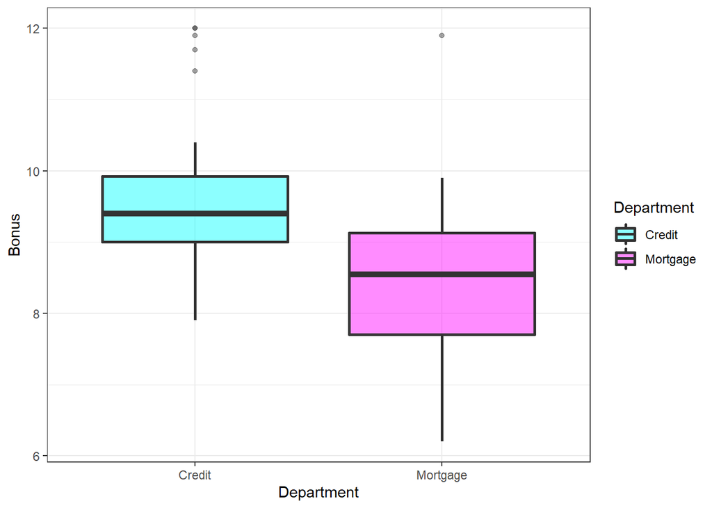

```r
data %>%
  ggplot(aes(x = Department, y = Bonus, fill=Department))+
  geom_boxplot(alpha=0.45, size=1)+
  scale_fill_manual(values = c("Credit" = "cyan",
                                "Mortgage" = "magenta"))+
  theme_bw()
```

#### 5. Write a brief paragraph explaining your findings to management. Are there any actions that should be considered as a result of your analysis?

The credit department has better bonus results than the mortgage department. Mortgage products are more complex than credit cards. There is no sufficient data to suggest a solution.

However, we need to investigate the entire mortgage process, the client’s income statement, credit score, the interest rates if it is competitive relative to the Fed Fund Rate, commission, and fees. In that case, we can spot potential problems and make better decisions.